# Progress Report 1

Lilith Appel, Jacob Posner, Mateo Useche

2024-04-11

```r
#Load packages
library(bayesrules)
library(tidyr)
library(tidyverse)
```

```r
library(ggplot2)
library(usmap)
library(sf)
library(rnaturalearth)
library(glmnet)
library(rstan)
library(rstanarm)
library(plotly)
```

# Research Question

Looking at patients who were diagnosed with breast cancer from 2015-2018, we want to study what parameters affected whether or not a breast cancer patient was diagnosed within 90 days of their first hospital visit. We also want to explore how accurate we can get with our predictions using a Bayesian lasso model.

# Data background

We use a dataset from Health Verity (HV), which is a large healthcare-related ecosystem specifically for US data. The data were created by a Kaggle challenge where they joined multiple datasets including health predictors, demographics, socioeconomic status, and zip codes. In particular, this HV dataset has patient-level data for individuals who were diagnosed with metastatic triple-negative breast cancers. Additionally, the dataset was merged with environmental databases to include toxic air pollution and its effect on labor outcomes. Moreover, we use a hospital dataset from all 50 US states and territories. We are hoping to eventually merge these two datasets so we can have all the demographic data and healthcare equity predictors and be able to analyze them with the spatial data from our second dataset. This data is geocoded and licensed by the US Government Works. For our analysis, our outcome of interest is whether or not a patient got diagnosed with breast cancer within the first 90 days. For our predictors, we have a lot of different options and we pulled 83 variables that could be important predictors. To list a few, we are interested in whether or not a patient is insured, race, age, zip code, and particulate matter pollution. We plan on creating a model that looks at the “best” predictors to include those in the model.

# Data Summaries

```r
breast_cancer<-read.csv("Data/training.csv")
hospitals<- read.csv("Data/Hospitals.csv")
```

```r
dim(breast_cancer)
```

```
## [1] 12906    83
```

```r
names(breast_cancer)
```

```
##  [1] "patient_id"
##  [2] "patient_race"
##  [3] "payer_type"
##  [4] "patient_state"
##  [5] "patient_zip3"
##  [6] "patient_age"
##  [7] "patient_gender"
##  [8] "bmi"
##  [9] "breast_cancer_diagnosis_code"
## [10] "breast_cancer_diagnosis_desc"
## [11] "metastatic_cancer_diagnosis_code"
## [12] "metastatic_first_novel_treatment"
## [13] "metastatic_first_novel_treatment_type"
## [14] "Region"
## [15] "Division"
```

[output cut: 68 more lines]

```r
head(breast_cancer)
```

```
##   patient_id patient_race         payer_type patient_state patient_zip3
## 1     475714                        MEDICAID            CA          924
## 2     349367        White         COMMERCIAL            CA          928
## 3     138632        White         COMMERCIAL            TX          760
## 4     617843        White         COMMERCIAL            CA          926
## 5     817482                      COMMERCIAL            ID          836
## 6     111545        White MEDICARE ADVANTAGE            NY          141
##   patient_age patient_gender   bmi breast_cancer_diagnosis_code
## 1          84          FALSE    NA                       C50919
## 2          62          FALSE 28.49                       C50411
## 3          43          FALSE 38.09                       C50112
## 4          45          FALSE    NA                       C50212
## 5          55          FALSE    NA                         1749
## 6          66          FALSE    NA                         1749
##                                   breast_cancer_diagnosis_desc
```

[output cut: 132 more lines]

```r
str(breast_cancer)
```

```
## 'data.frame':    12906 obs. of  83 variables:
##  $ patient_id                           : int  475714 349367 138632 617843 817482 111545 914071 479368 994014 155485 ...
##  $ patient_race                         : chr  "" "White" "White" "White" ...
##  $ payer_type                           : chr  "MEDICAID" "COMMERCIAL" "COMMERCIAL" "COMMERCIAL" ...
##  $ patient_state                        : chr  "CA" "CA" "TX" "CA" ...
##  $ patient_zip3                         : int  924 928 760 926 836 141 900 619 973 617 ...
##  $ patient_age                          : int  84 62 43 45 55 66 51 60 82 64 ...
##  $ patient_gender                       : logi  FALSE FALSE FALSE FALSE FALSE FALSE ...
##  $ bmi                                  : num  NA 28.5 38.1 NA NA ...
##  $ breast_cancer_diagnosis_code         : chr  "C50919" "C50411" "C50112" "C50212" ...
##  $ breast_cancer_diagnosis_desc         : chr  "Malignant neoplasm of unsp site of unspecified female breast" "Malig neoplm of upper-outer quadrant of right female breast" "Malignant neoplasm of central portion of left female breast" "Malig neoplasm of upper-inner quadrant of left female breast" …
##  $ metastatic_cancer_diagnosis_code     : chr  "C7989" "C773" "C773" "C773" ...
##  $ metastatic_first_novel_treatment     : chr  "" "" "" "" ...
##  $ metastatic_first_novel_treatment_type: chr  "" "" "" "" ...
##  $ Region                               : chr  "West" "West" "South" "West" ...
```

[output cut: 69 more lines]

```r
dim(hospitals)
```

```
## [1] 7570   34
```

```r
names(hospitals)
```

```
##  [1] "X"          "Y"          "OBJECTID"   "ID"         "NAME"
##  [6] "ADDRESS"    "CITY"       "STATE"      "ZIP"        "ZIP4"
## [11] "TELEPHONE"  "TYPE"       "STATUS"     "POPULATION" "COUNTY"
## [16] "COUNTYFIPS" "COUNTRY"    "LATITUDE"   "LONGITUDE"  "NAICS_CODE"
## [21] "NAICS_DESC" "SOURCE"     "SOURCEDATE" "VAL_METHOD" "VAL_DATE"
## [26] "WEBSITE"    "STATE_ID"   "ALT_NAME"   "ST_FIPS"    "OWNER"
## [31] "TTL_STAFF"  "BEDS"       "TRAUMA"     "HELIPAD"
```

```r
head(hospitals)
```

```
##           X        Y OBJECTID        ID
## 1 -94.94548 29.74762     8497  76777520
## 2 -82.88184 40.02714     8498 129043230
## 3 -84.16803 39.77424     8499 130045404
## 4 -80.63297 41.00517     8500 128844512
## 5 -84.19940 39.74774     8501 129845417
## 6 -96.92710 35.29726     8502 130774801
##                                                      NAME
## 1 HOUSTON METHODIST SAN JACINTO HOSPITAL ALEXANDER CAMPUS
## 2                                   WOODS AT PARKSIDE,THE
## 3                              DAYTON CHILDREN'S HOSPITAL
## 4                       VIBRA HOSPITAL OF MAHONING VALLEY
## 5                  HAVEN BEHAVIORAL SENIOR CARE OF DAYTON
## 6                    CHG CORNERSTONE HOSPITAL OF OKLAHOMA
##                              ADDRESS     CITY STATE   ZIP          ZIP4
```

[output cut: 62 more lines]

```r
str(hospitals)
```

```
## 'data.frame':    7570 obs. of  34 variables:
##  $ X         : num  -94.9 -82.9 -84.2 -80.6 -84.2 ...
##  $ Y         : num  29.7 40 39.8 41 39.7 ...
##  $ OBJECTID  : int  8497 8498 8499 8500 8501 8502 8503 8504 8505 8506 ...
##  $ ID        : int  76777520 129043230 130045404 128844512 129845417 130774801 131074538 5258701 10527016 77677090 ...
##  $ NAME      : chr  "HOUSTON METHODIST SAN JACINTO HOSPITAL ALEXANDER CAMPUS" "WOODS AT PARKSIDE,THE" "DAYTON CHILDREN'S HOSPITAL" "VIBRA HOSPITAL OF MAHONING VALLEY" ...
##  $ ADDRESS   : chr  "1700 JAMES BOWIE DRIVE" "349 OLDE RIDENOUR ROAD" "ONE CHILDRENS PLAZA" "8049 SOUTH AVENUE" ...
##  $ CITY      : chr  "BAYTOWN" "COLUMBUS" "DAYTON" "BOARDMAN" ...
##  $ STATE     : chr  "TX" "OH" "OH" "OH" ...
##  $ ZIP       : int  77520 43230 45404 44512 45417 74801 74538 58701 27016 77090 ...
##  $ ZIP4      : chr  "NOT AVAILABLE" "NOT AVAILABLE" "NOT AVAILABLE" "NOT AVAILABLE" ...
##  $ TELEPHONE : chr  "(281) 420-8765" "(614) 471-2552" "(937) 641-3300" "(330) 726-5021" ...
##  $ TYPE      : chr  "GENERAL ACUTE CARE" "SPECIAL" "CHILDREN" "LONG TERM CARE" ...
##  $ STATUS    : chr  "OPEN" "OPEN" "OPEN" "OPEN" ...
##  $ POPULATION: int  182 50 155 45 32 34 20 251 93 16 ...
```

[output cut: 20 more lines]

# Data Viz

```r
hospital_data_per_state <- hospitals %>%
  group_by(STATE) %>%
  summarise(total_hospitals = n()) %>%
  arrange(desc(total_hospitals))
```

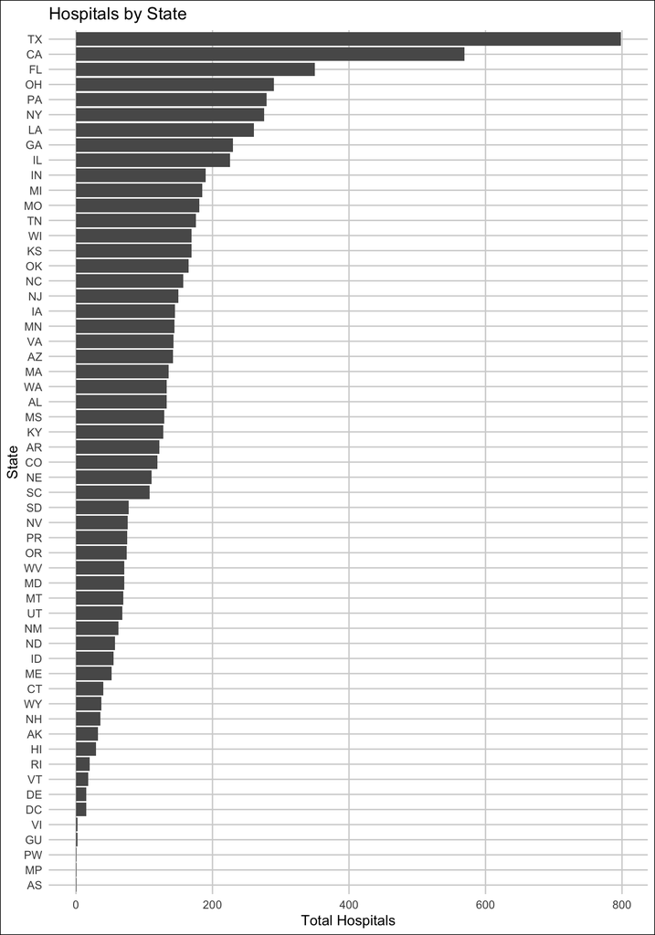

```r
# Hospitals by State
  ggplot(hospital_data_per_state, aes(x = reorder(STATE, total_hospitals), y = total_hospitals)) +
  geom_bar(stat = "identity") +
  theme(
    plot.title = element_text(size = 20),  # Adjust the title size
    axis.title.x = element_text(size = 16),  # Adjust x-axis label size
    axis.title.y = element_text(size = 16),  # Adjust y-axis label size
    axis.text.x = element_text(size = 15),  # Adjust x-axis tick label size
    axis.text.y = element_text(size = 8),  # Adjust y-axis tick label size
    legend.text = element_text(size = 14)  # Adjust legend text size
  ) +
  theme_minimal() +  # You can use a different theme if you prefer
  theme(
    plot.background = element_rect(fill = "white"),  # Set plot background color
    panel.grid.major = element_line(color = "lightgray"),  # Adjust major gridlines
    panel.grid.minor = element_blank()  # Remove minor gridlines
  ) +
  labs(
    title = "Hospitals by State",
    x = "State",
    y = "Total Hospitals"
  ) +
  coord_flip()
```

Texas, California, and Florida lead the U.S. in number of hospitals. We could expand on this by looking at hospitals per people because those states have the highest population, so it makes sense that there would be more hospitals.

```r
#Map of total hospitals per state
hospital_data_per_state <- hospital_data_per_state %>%
  dplyr::rename(state = STATE)
```

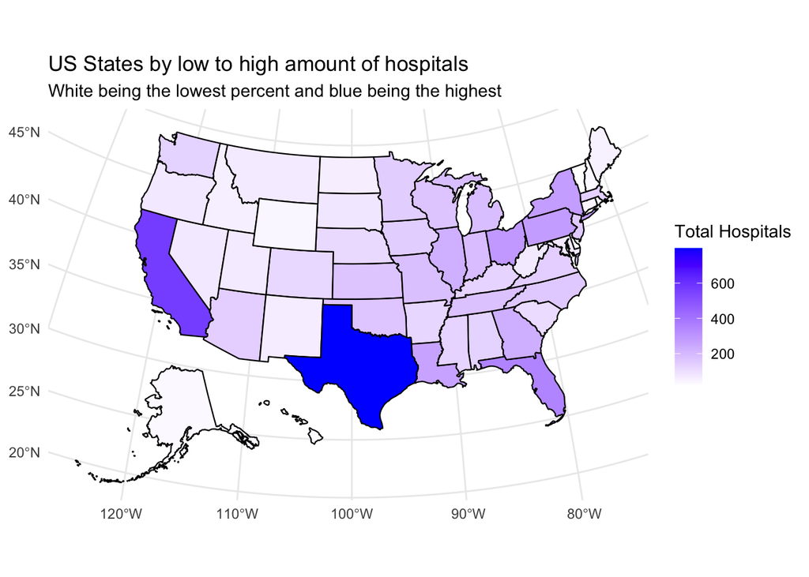

```r
MapOfStatesTotalHospitals <- plot_usmap(data = hospital_data_per_state, values = "total_hospitals", region = "state") +
  labs(title = "US States by low to high amount of hospitals",
       subtitle = "White being the lowest percent and blue being the highest") +
  scale_fill_continuous(low = "white", high = "blue", name = "Total Hospitals", label = scales::comma) +
  theme_minimal()

MapOfStatesTotalHospitals
```

```r
health_data_perc <- breast_cancer %>%
  filter(!is.na(payer_type) & payer_type != "") %>%
  filter(!is.na(DiagPeriodL90D) & DiagPeriodL90D != "") %>%
  group_by(DiagPeriodL90D, payer_type) %>%
  summarise(count = n()) %>%
  mutate(percentage = count / sum(count) * 100)
```

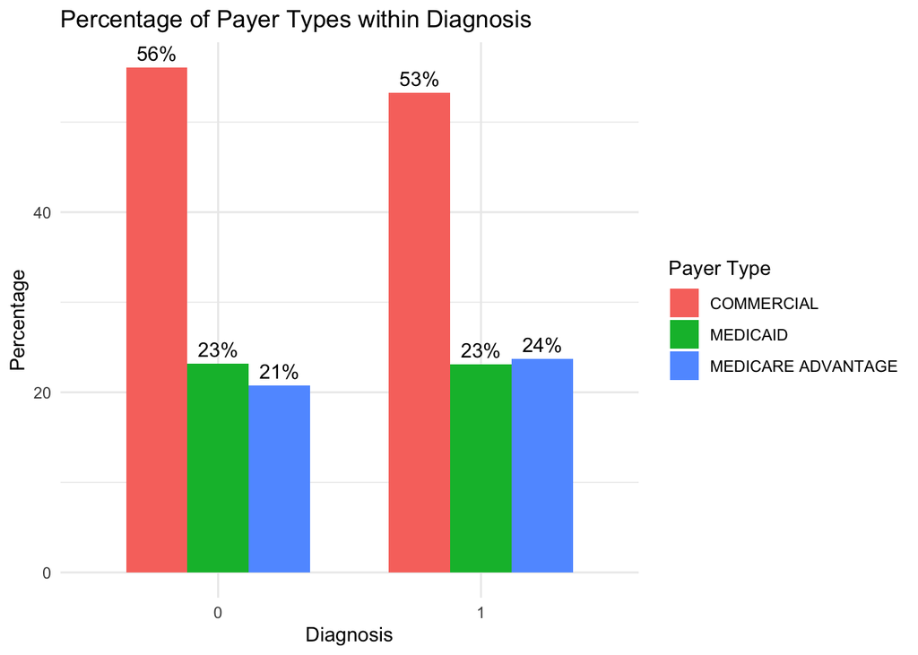

```r
health_data_perc %>%
ggplot(aes(x = as.factor(DiagPeriodL90D), y = percentage, fill = payer_type)) +
  geom_bar(stat = "identity", position = "dodge", width = 0.7) +
  geom_text(aes(label = paste0(round(percentage), "%")), position = position_dodge(width = 0.7), vjust = -0.5) +
  scale_fill_discrete(name = "Payer Type") +
  labs(x = "Diagnosis", y = "Percentage", title = "Percentage of Payer Types within Diagnosis") +
  theme_minimal()
```

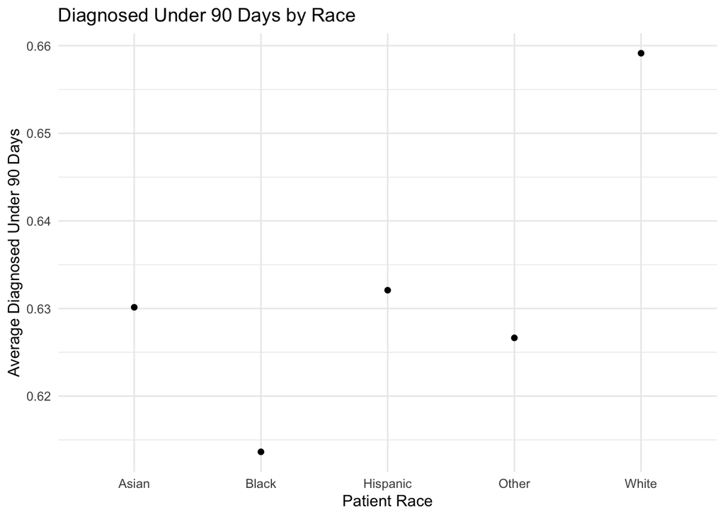

```r
#Diagnosed within 90 days by race
diag_race<-breast_cancer %>%
  filter(!is.na(patient_race) & patient_race != "") %>%
  filter(!is.na(DiagPeriodL90D) & DiagPeriodL90D != "") %>%
  group_by(patient_race) %>%
  summarise(avg_diag_90 = mean(DiagPeriodL90D))

ggplot(diag_race, aes(x=patient_race, y=avg_diag_90))+
  geom_point()+
  labs(x="Patient Race", y="Average Diagnosed Under 90 Days", title = "Diagnosed Under 90 Days by Race")+
  theme_minimal()
```

While the averages are somewhat close, we notice that white people get diagnosed within 90 days more than any other race while black people are diagnosed before 90 days at lower rates.

# Model Building

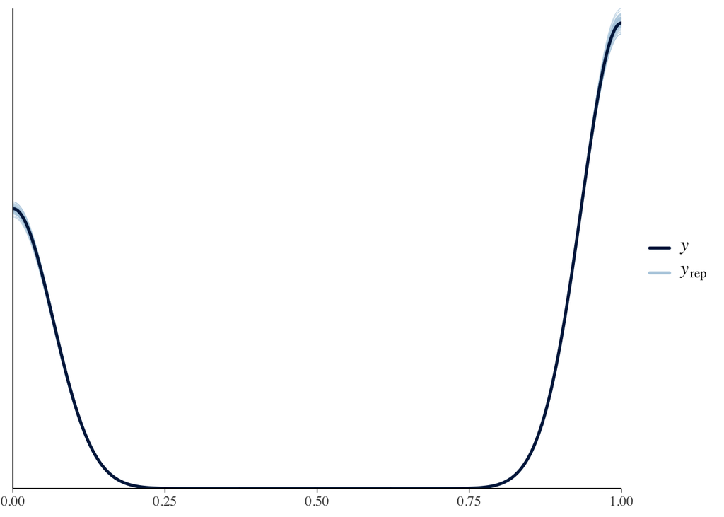

```r
#Model
diag_post <- stan_glm(
 DiagPeriodL90D  ~ patient_race,
  family = binomial,
  prior_PD = FALSE,
  data = breast_cancer,
  chains = 4, iter = 5000*2, seed = 84735, refresh = 0)

pp_check(diag_post)
```

# Next Steps

Our final material will be in a blog post. In our next steps, we want to further explore which predictors we should use in model creation, use cross validation to see how good our models are, create visualizations of what our models tell us, and create plots that show our MCMC chains, to (hopefully) show stable chains.